# Trzeci etap

Adrianna Wlazło, Patrycja Faszczewska

7 grudnia 2016

# Ocena klasyfikatorów

Ocenę przeprowadzimy przy podziale na modele regresjii i modele typu boosting/bagging. Wylosujemy 100 razy zbiór testowy zawierający 75% zbioru wejściowego, z zachowaniem proporcji pacjentów o różnych stanach po roku. Porównywanie wszystkich klasyfikatorów zastosujemy na tej samej próbie zbiorów testowych. Jakość otrzymanych klasyfikatorów zbadamy w oparciu o współczynnik stosowany w kaggle,błąd w krosswalidacji, pole pod krzywą ROC oraz błąd MSE.

## Modele regresji (lasso, ridge, elastic net)

W celu uniknięcia przeuczenia modelu regresji liniowej zregularyzujemy regresję 3 metodami: lasso, ridge oraz elastic net. W efekcie przeprowadzonej analizy wybierzemy najskuteczniejszą z metod regularyzacji dla prezentowanego modelu, która posłuży nam do zbudowania modelu opartego o kilka najlepszych klasyfikatorów.

### Błąd średniokwadratowy

Przydatne może być porównanie błędu średniokwadratowego dla różnych lambd w każdym z modeli. Spójrzmy zatem na wykresy przedstawiające MSE dla każdego z klasyfikatorów w zależności od wartości lambdy ograniczającej współczynniki w modelu regresji:

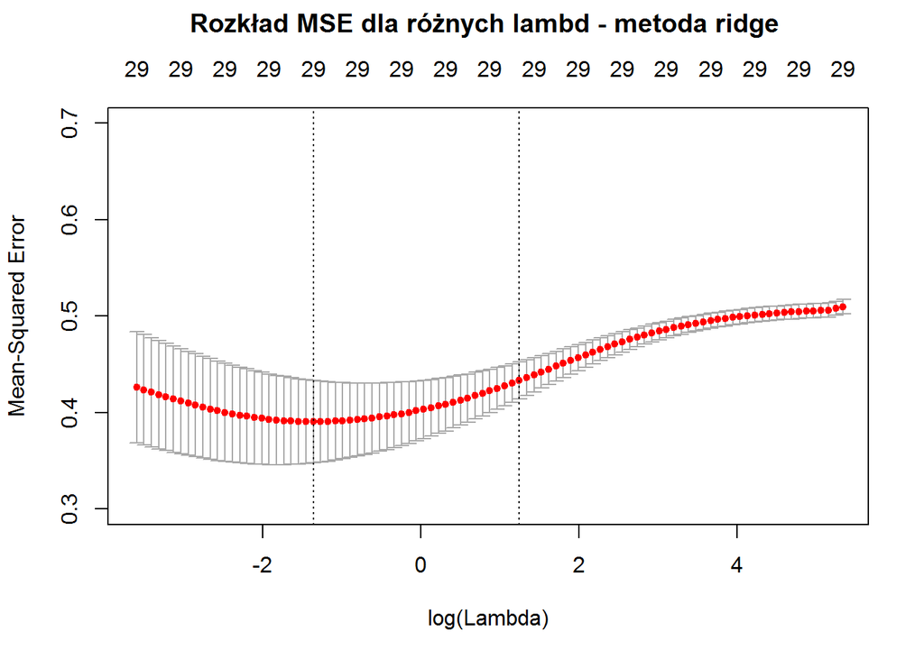

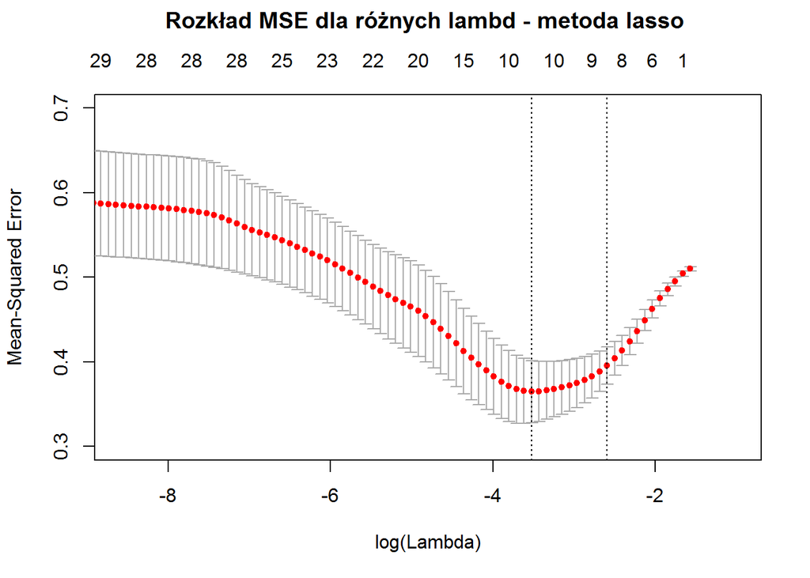

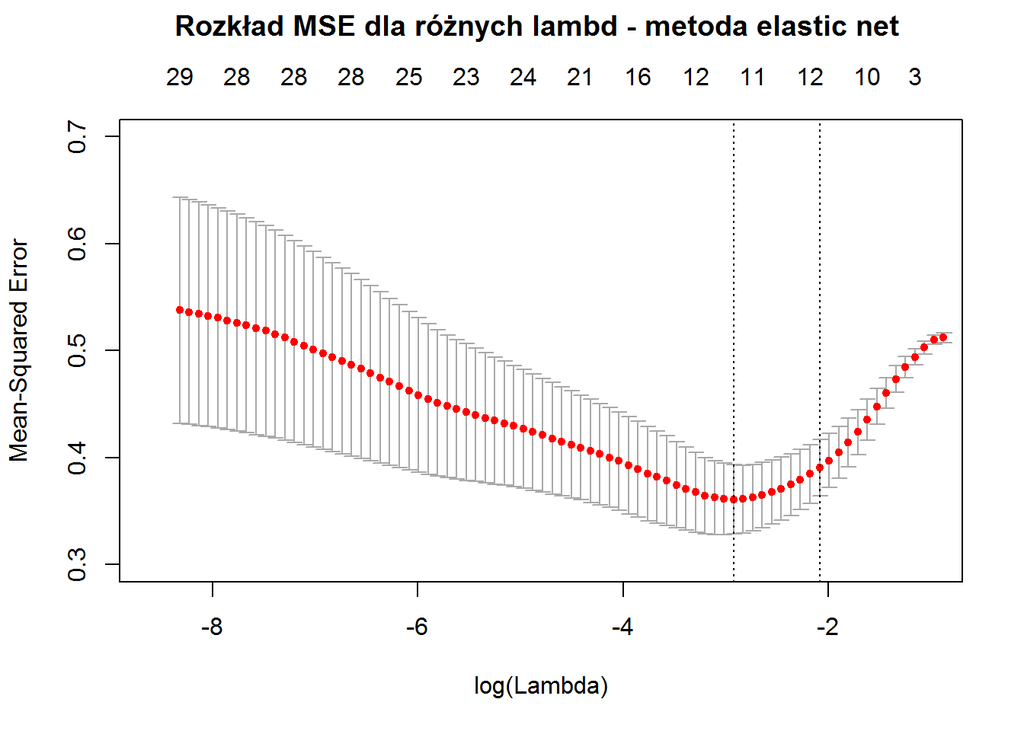

Jak widzimy wykresy te są podobne w przypadku regularyzacji lasso i elastic net. Jak później pokażemy metody te mają podobną skutecznośc w przypadku prezentowanego problemu i miar jakości klasyfikacji, które zdecydowałyśmy się zastosować.

### Miara dopasowania z platformy Kaggle

Warto przyjrzeć się, jakie wyniki potencjalnie można uzyskać każdą z metod na platformie Kaggle. Współczynnik f1 mierzy wartości “precision” i “recall” i faworyzyje takie predykcje, gdzie owe miary są do siebie jak najbardziej zbliżone. Poniżej przedstawiamy rozkłady miary f1 w zależności od metody:

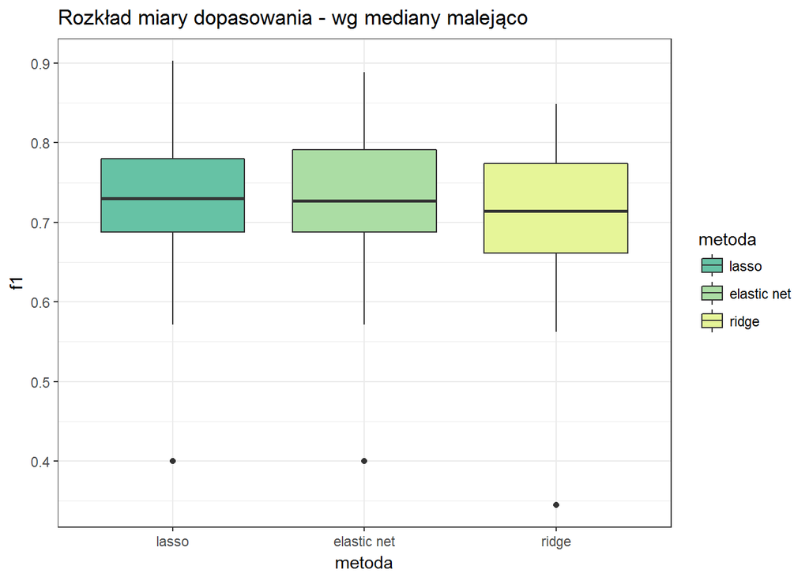

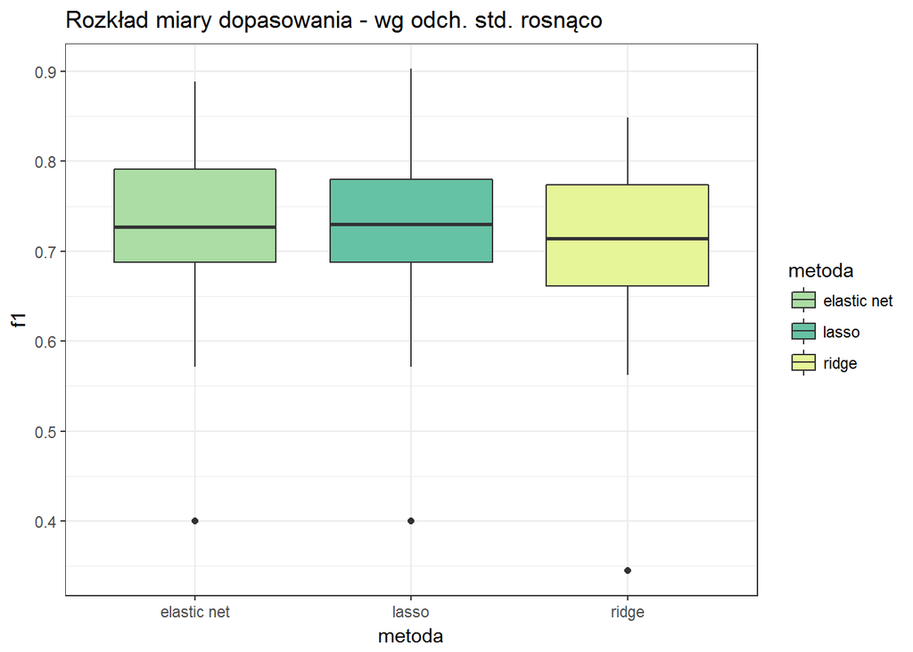

Pierwszy z przedstawionych wykresów prezentuje wybrane metody w kolejności malejącej biorąc pod uwagę medianę rozkładu, natomiast drugi pod względem odchylenia standardowego. Wykresy te są wygodne w interpretacji. Im wyższa wartość f1 tym model lepiej przewidywał dane (uzyskane rozkłady wskaźników otrzymane są przy 100-krotnym losowaniu zbioru uczącego). Zatem rozkład współczynnika sugeruje wybór elastic net bądź lasso.

### Pole pod krzywą ROC

Kolejnym narzędziem porównywania klasyfikatorów jest pole pod krzywą ROC dla miar “specifity” i “sensitivity”. Im wyższe pole tym lepszy klasyfikator. Wykresy krzywych ROC dla prezentowanych klasyfikatorów wyglądają następująco:

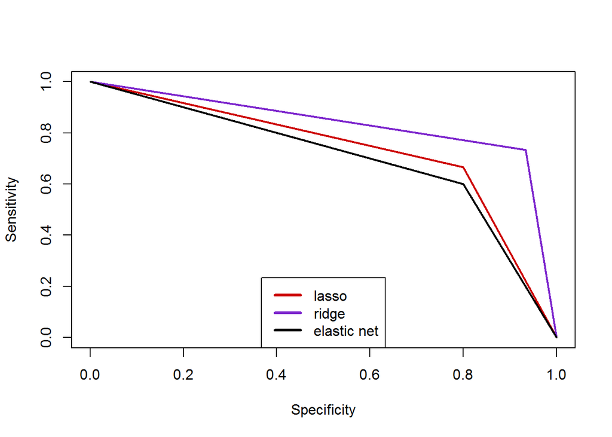

Zbadajmy, jak zachowuje się pole pod krzywą ROC na 100 replikacjach zbioru testowego dla każdego z klasyfikatorów. Osiągnięte rezultaty prezentujemy poniżej.

```
## Średnie pola pod wykresem krzywej ROC:
##  0.716   Ridge
##  0.7283333   Lasso
##  0.729   Elastic net
```

### Cross walidacja

Porównamy również błędy otrzymane podczas przeprowadzania crosswalidacji.(N-fold cv) Ze względu na mały rozmiar danych przeprowadzimy N-fold crosswalidacje. Jej wyniki prezentujemy poniżej.

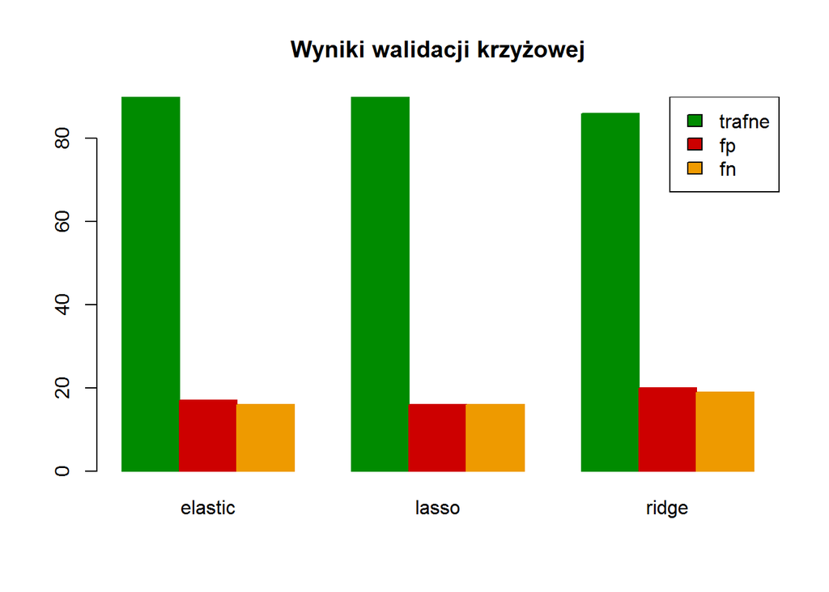

```
## Średnie błędy klasyfikatorów otrzymane w crosswalidacji:
##  0.312   Ridge
##  0.256   Lasso
##  0.264   Elastic net
```

Po raz kolejny otrzymujemy podobną jakość w przypadku elastic net i lasso, które osiągneły mniejszy błąd aniżeli regularyzacja ridge. Bład ten utrzymuje się na poziomie ok. 26%.

## Metody adaboost,xgboost,bagging i random forest

Analogiczną analizę przeprowadzimy dla metod boosting/bagging. Metody te oparte są o komitety innych reguł i mają na celu obniżenie obciążenia/wariancji błędu predykcji. Prezentowane przez nas modele konstruujemy za pomocą funkcji adaboost, xgboost (boosting) oraz bagging, random forest (bagging).

### Błąd średniokwadratowy

Podobnie jak wcześniej pierwszą miarą, która zastosujemy w celu porównania wyżej wspomnianych funkcji jest błąd średniokwadratowy. Tym razem porówname rozkład MSE otrzymany przy 100-krotnym wylosowaniu zbioru uczącego.

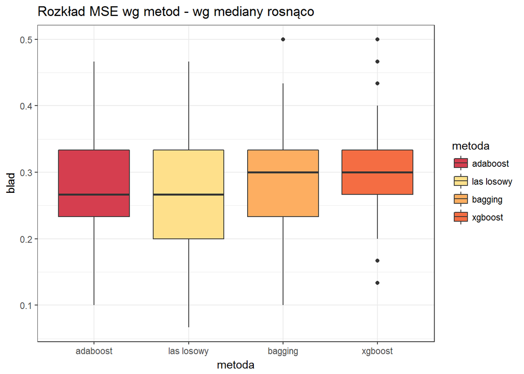

```
## Błąd średniokwadratowy:
##  0.2803333  adaboost
##  0.2686667 las losowy
##  0.2986667 bagging
##  0.295 xgboost
```

Analiza błędu średniokwadratowego wskazuje na wybór metody lasóW losowych oraz adaboost - mają one stosunkowo mały i dość stabilny MSE.

### Współczynnik dopasowania z platformy Kaggle

Kolejnym krokiem analizy będzie porównanie współczynnika stosowanego na platformie Kaggle.

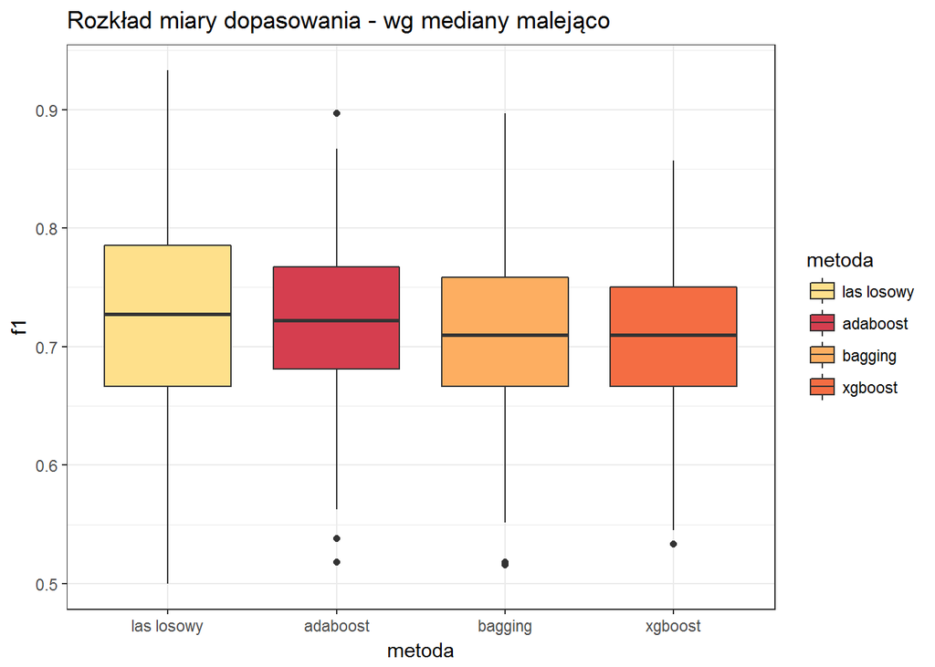

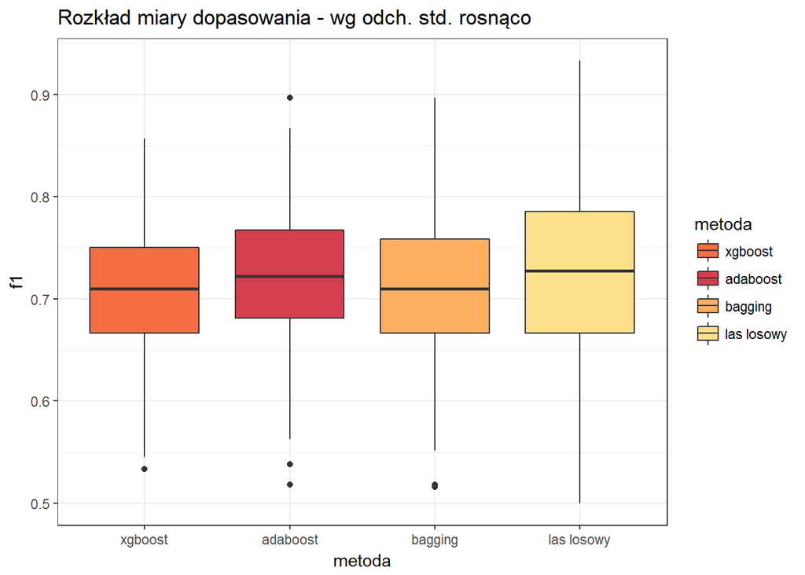

Powyższe wykresy przedstawiają rozkłady miary f1 dla różnych metod- pierwszy wg mediany malejaco, drugi wg odchylenia standardowego rosnąco. Na podstawie tej analizy skłaniamy się ku wyborze metody adaboost, ze względu na stosunkowo dobre dopasowanie przy zachowaniu mniejszego odchylenia.

### Pole pod krzywą ROC

Krzywe ROC dla wymienionych wyżej funkcji umieszczone są poniżej,

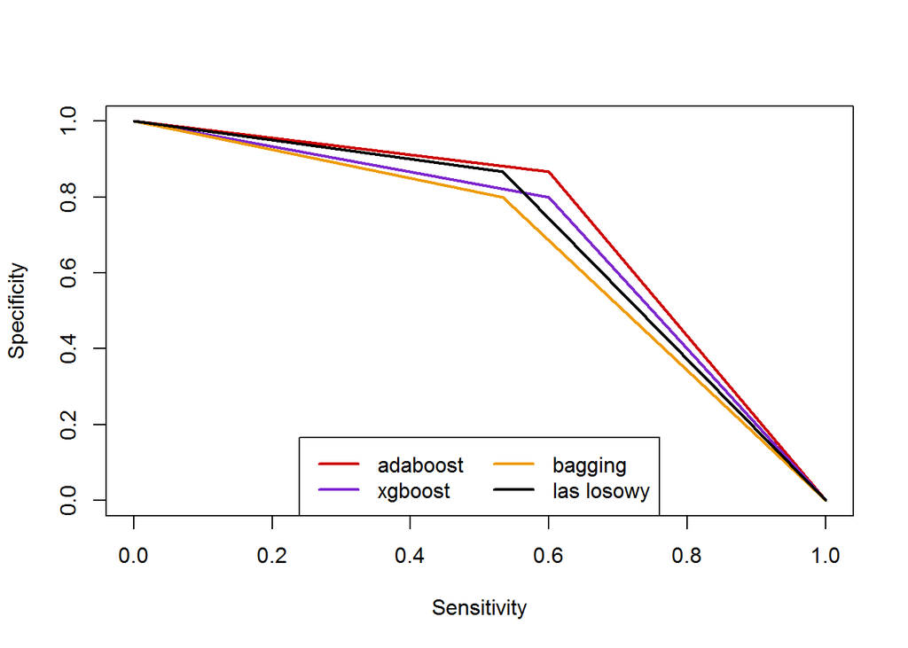

```
## Średnie pola pod wykresem krzywej ROC:
##  0.7196667   Adaboost
##  0.7313333   Las losowy
##  0.705   Xgboost
##  0.7013333   Bagging
```

Największe średnie pole pod wykresem uzyskałyśmy dla metody lasu losowego, metoda adaboost jest na drugim miejscu. W przypadku funkcji xgboost oraz bagging pole pod wykresem wynosi średnio ok.0.70 i jest zdecydowanie słabszym rezultatem.

### Cross walidacja

Jak wcześniej przeprowadzimy 125-fold cross-walidacje w celu porównania średniej trafności predykcji.

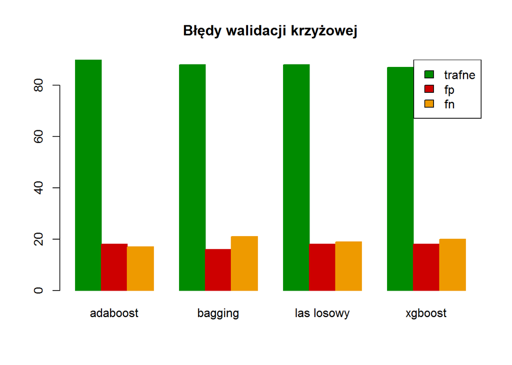

```
## Średnie błędy cross-walidacji:
##  0.28  adaboost
##  0.296 las losowy
##  0.296 bagging
##  0.304 xgboost
```

Również 125-fold cross walidacja delikatnie wskazuje na mniejszą ilość pomyłek dla metody adaboost, która skutecznie przewidywała stan pacjenta po roku w ok. 72% przypadków.

## Konstrukcja modelu łączącego najlepsze z prezentowanych metod

W ostatnim kroku postaramy się połączyć najlepsze z prezentowanych metod aby skonstruować model, który najlepiej przewidzi stan pacjenta po roku. Konstrukcja ta będzie opierała się na funkcjach adaboost, las losowy oraz regularyzacja regresji liniowej elastic net. Zgodnie z przeprowadzoną analizą są to najlepsze klasyfikatory reprezentujące każde z podejść (regularyzację regresji, boosting, bagging).  
(“Majority voting”) Końcowa predykcja w konstruowanym przez nas modelu będzie brała pod uwagę “głosy” każdej z wybranych funkcji i wybierała wartość która pojawi się najczęściej. Oczywiście, aby ocenić tak skonstruowany model porównamy go z pozostałymi klasyfikatorami. Analiza ta pozwoli nam wyłonić najlepszy z prezentowanych przez nas modeli.  
Zdecydowałyśmy się również na zaprezentowanie metody predykcji, którą nazwałyśmy “demokracja”.Model ten działa następująco: w przypadku zgodności predykcji modeli xgboost,lasso oraz bagging uznaje je za prawdziwe, natomiast gdy uzyskane w tych modelach predykcje różnią się to uznaje predykcję modelu adaboost za słuszną.

### Błąd średniokwadratowy

Błąd średniokwadratowy dla najlepszych klasyfikatorów kształtuje się następująco:

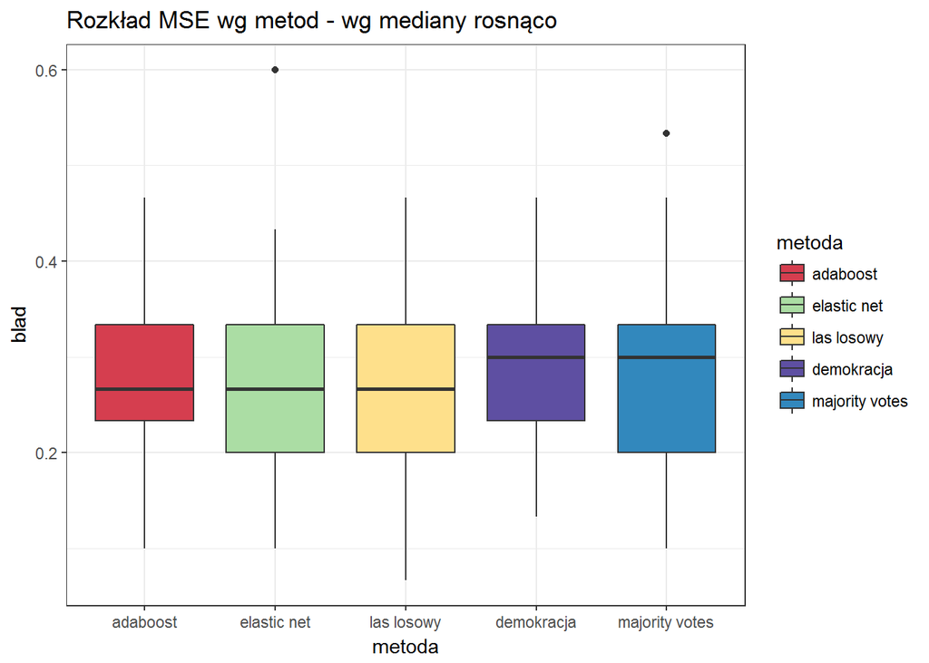

```
## Błąd średniokwadratowy:
##  0.273  elastic net
##  0.2803333  adaboost
##  0.2686667  las losowy
##  0.2853333  demokracja
##  0.2713333  majority votes
```

Najniższy błąd prezentuje las losowy. Natomiast drugi co do wielkości błąd średniokwadratowy ma wprowadzony tutaj model łączący pozostałe klasyfikatory, biorący pod uwagę przewidywania pozostałych klasyfikatorów.

### Miara dopasowania z platformy Kaggle

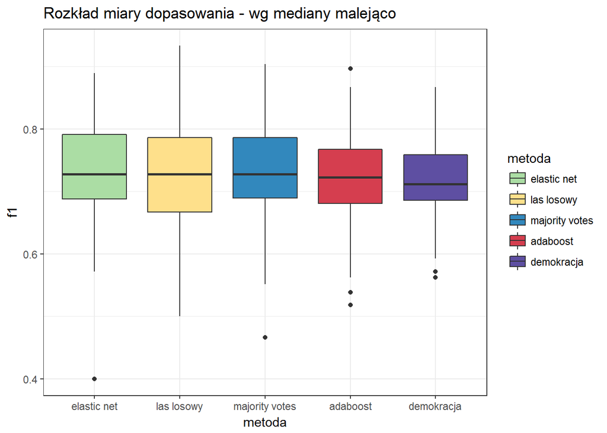

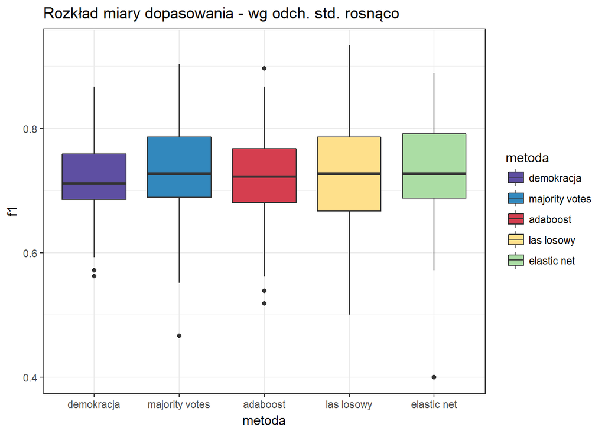

Wykresy prezentujące rozkład współczynnika f1 wyróżniają metody elastic net oraz majority votes.

### Pole pod krzywą ROC

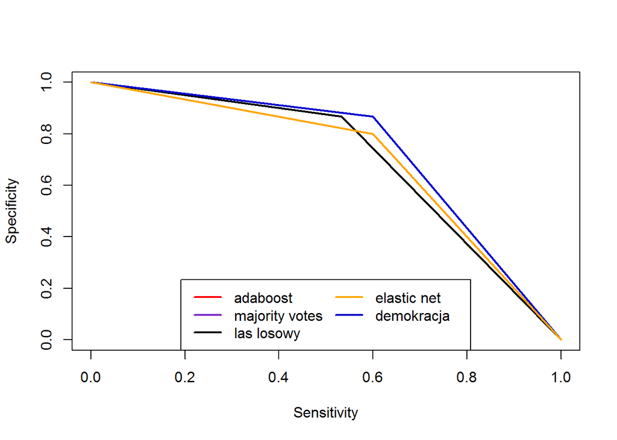

```
## Średnie pola pod wykresem krzywej ROC:
##  0.729       Elastic net
##  0.7196667   Adaboost
##  0.7313333   Las losowy
##  0.7146667  Demokracja
##  0.7293333   Majority votes
```

Najwyższe średnie pole pod wykresem krzywej ROC uzyskał las losowy, jednak niewiele mniejsze średnie pole uzyskała metoda “majority votes”.

### Cross walidacja

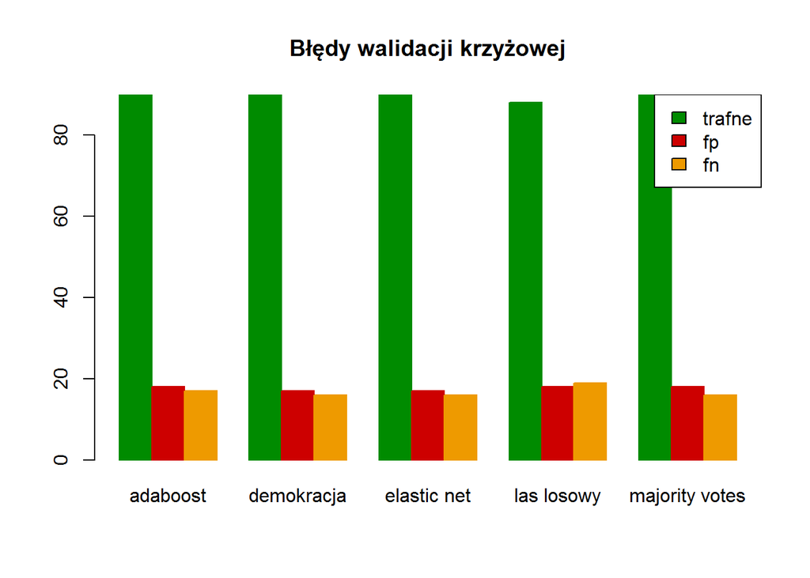

```
## Średnie błędy cross-walidacji:
##  0.28  adaboost
##  0.296 las losowy
##  0.264 elastic net
##  0.264 demokracja
##  0.272 majority votes
```

Najniższy średni błąd otrzymany w krosswalidacji należy do metod elastic net oraz “demokracja”. Drugi co do wielkośći błąd należy do “majority votes”.

Jak widzimy każda z przedstawionych miar wysoko plasuje model “majority votes” w porównaniu z pozostałymi klasyfikatorami, co skłania nas do wybory właśnie tej metody.